# **Project 4**

### **The Problem**

Sleep is something everyone needs, and to be honest, something that many people look forward to every day. But far too often, the problem of sleeping poorly or not at all plagues countless individuals. One would think there is some type of connetion between those who suffer from low amounts of sleep, but how exactly would we determine this. In this project, I hope to find distinctions of those who may suffer from sleep problems so that we can develop a better understanding of why and possibly how their sleep problems may be combated.

### **Clustering and How it Works**

This project will use both agglomerative and k-means clustering. Clustering refers to a group of machine learning algorithms that attempt to take observations and place them into specific groups or clusters based on a number of similarities and likenesses. It should be recognized that clustering does not classify observation, but simply places them into a cluster of other like observations. K means clustering works by selecting the number of desired clusters, placing the centers of the clusters randomly throughout the data, and assigning the surrounding points to their nearest cluster. The center of each cluster is then moved to the average of all of the points contained within, then the process is repeated until the cluster centers do not move. Agglomerative clustering is a much more simple than k-means, with each point beginning as its own cluster, and points consecutively being clustered with their next closest cluster, until all points are incorporated into one cluster.

```python
import pandas as pd
import numpy as np
import seaborn as sns
import matplotlib.pyplot as plt
from sklearn.decomposition import PCA
from sklearn.cluster import KMeans,AgglomerativeClustering
from sklearn.preprocessing import StandardScaler
import warnings
warnings.filterwarnings('ignore')
```

### **The Data**

This data was found on kaggle and is a csv containing 34 features, including age, wage, education level, and a variety of other variables. Some of the variables we are particularly interested in are the amount of sleep, leisure time and work time an individual has every week. Link to dataset: https://www.kaggle.com/datasets/kapturovalexander/sleep-patterns

```python
df = pd.read_csv('sleep75.csv')
print(df.columns)
df = df.drop(columns=['case','hrwage','lhrwage','earns74','smsa','lothinc','agesq','leis1','leis2','leis3','worknrm','workscnd'])
df.head()
```

```
Index(['age', 'black', 'case', 'clerical', 'construc', 'educ', 'earns74',
       'gdhlth', 'inlf', 'leis1', 'leis2', 'leis3', 'smsa', 'lhrwage',
       'lothinc', 'male', 'marr', 'prot', 'rlxall', 'selfe', 'sleep',
       'slpnaps', 'south', 'spsepay', 'spwrk75', 'totwrk', 'union', 'worknrm',
       'workscnd', 'exper', 'yngkid', 'yrsmarr', 'hrwage', 'agesq'],
      dtype='object')
```

|  | age | black | clerical | construc | educ | gdhlth | inlf | male | marr | prot | ... | sleep | slpnaps | south | spsepay | spwrk75 | totwrk | union | exper | yngkid | yrsmarr |
| --- | --- | --- | --- | --- | --- | --- | --- | --- | --- | --- | --- | --- | --- | --- | --- | --- | --- | --- | --- | --- | --- |
| 0 | 32 | 0 | 0.0 | 0.0 | 12 | 0 | 1 | 1 | 1 | 1 | ... | 3113 | 3163 | 0 | 0 | 0 | 3438 | 0 | 14 | 0 | 13 |
| 1 | 31 | 0 | 0.0 | 0.0 | 14 | 1 | 1 | 1 | 0 | 1 | ... | 2920 | 2920 | 1 | 0 | 0 | 5020 | 0 | 11 | 0 | 0 |
| 2 | 44 | 0 | 0.0 | 0.0 | 17 | 1 | 1 | 1 | 1 | 0 | ... | 2670 | 2760 | 0 | 20000 | 1 | 2815 | 0 | 21 | 0 | 0 |
| 3 | 30 | 0 | 0.0 | 0.0 | 12 | 1 | 1 | 0 | 1 | 1 | ... | 3083 | 3083 | 0 | 5000 | 1 | 3786 | 0 | 12 | 0 | 12 |
| 4 | 64 | 0 | 0.0 | 0.0 | 14 | 1 | 1 | 1 | 1 | 1 | ... | 3448 | 3493 | 0 | 2400 | 1 | 2580 | 0 | 44 | 0 | 33 |

5 rows × 22 columns

### **Visualization**

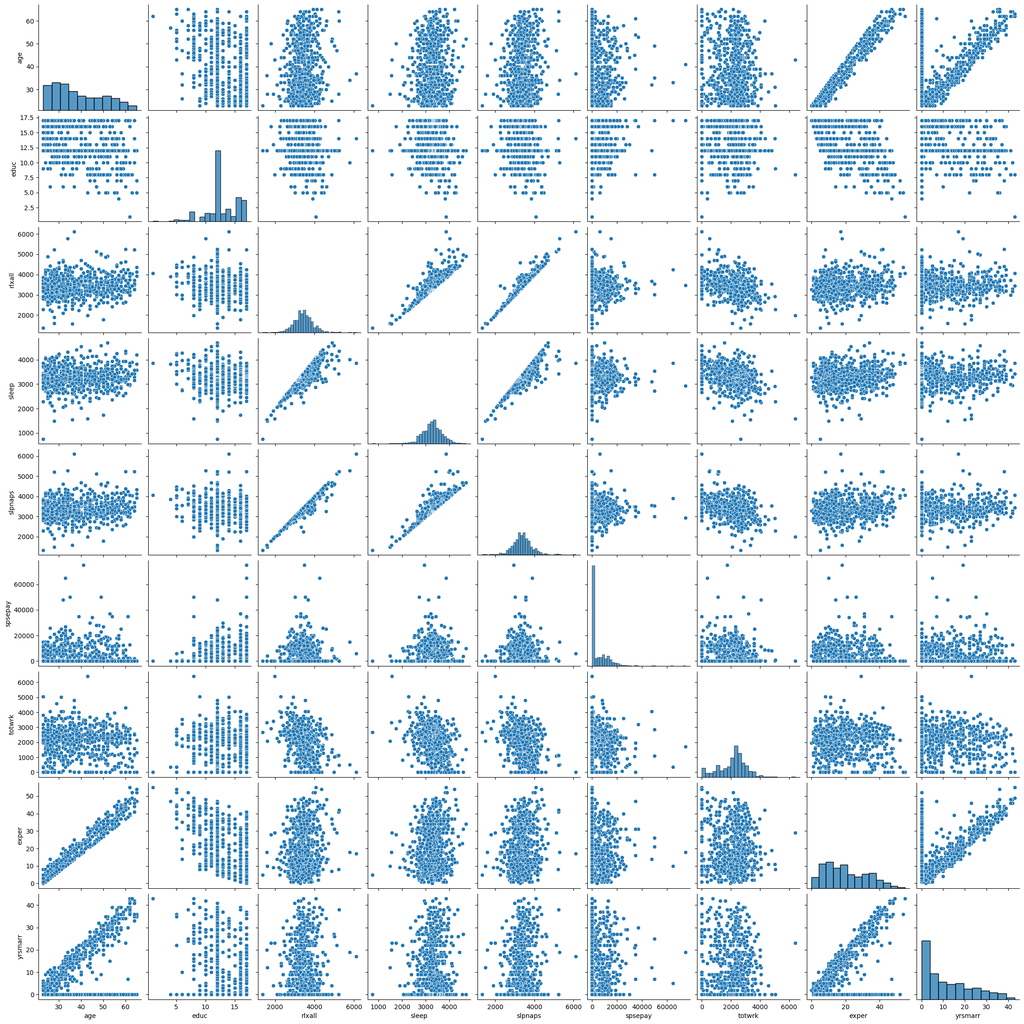

```python
sns.pairplot(df.drop(columns=['black','clerical','construc','gdhlth','inlf','male','marr','prot','selfe','south','spwrk75','union','yngkid']))
```

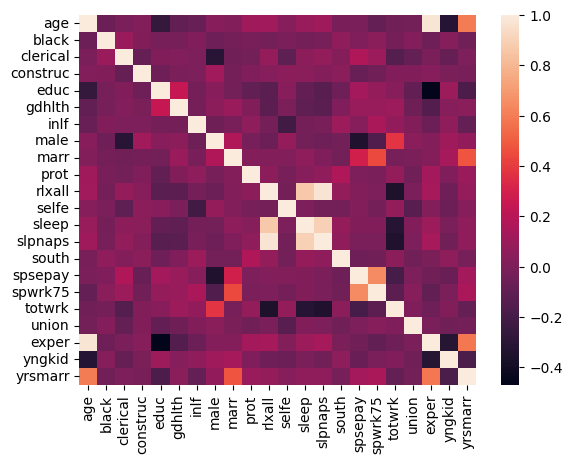

```python
sns.heatmap(df.corr())
```

### **Pre-Processing**

```python
df.isna().sum()
```

```
age         0
black       0
clerical    0
construc    0
educ        0
gdhlth      0
inlf        0
male        0
marr        0
prot        0
rlxall      0
selfe       0
sleep       0
slpnaps     0
south       0
spsepay     0
spwrk75     0
totwrk      0
union       0
exper       0
yngkid      0
yrsmarr     0
dtype: int64
```

### **Modeling**

In terms of modeling, I decided to begin with reducing down the number of features included to make it a bit easier to visualize the relationships between our clusters using PCA. I also wanted to see how each clustering method would separate the data, so also decided to go through the process using both k-means and agglomerative clustering.

```python
#Beginning with creating the two dimension PCA
df_std_pre = df[['age','educ','rlxall','sleep','slpnaps','spsepay','totwrk','exper','yrsmarr']].values
df_std = StandardScaler().fit_transform(df_std_pre)
pca = PCA(n_components=2)
pca_mod = pca.fit_transform(df_std)
pca_std = pd.DataFrame(pca_mod)
```

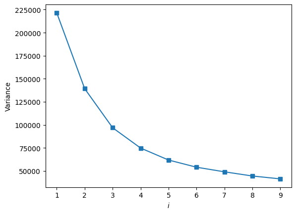

```python
inertia = []
for i in range(1,10):
    clus = KMeans(n_clusters=i, random_state=3).fit(df_std_pre)
    inertia.append(np.sqrt(clus.inertia_))
plt.plot(range(1,10),inertia,marker='s');
plt.xlabel('$i$')
plt.ylabel('Variance')
```

Here we are trying to determine how many clusters we want present for our k-means clustering using the elbow method. While it seems difficult to determine just how many clusters we want the sharpest turn in our line appears to be at either 2 or 3 clusters.

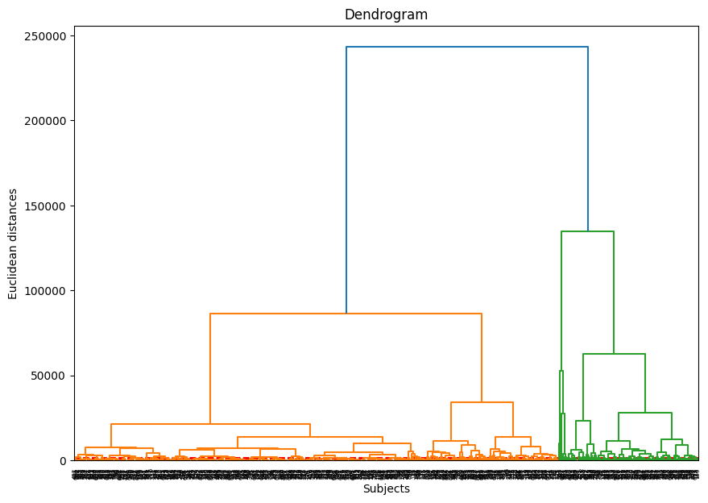

```python
import scipy.cluster.hierarchy as shc
plt.figure(figsize=(10, 7))
plt.title('Dendrogram')
plt.xlabel('Subjects')
plt.ylabel('Euclidean distances')
plt.axhline(y=825, color='r', linestyle='--')
plt.axhline(y=1575, color='r', linestyle='--')
dend = shc.dendrogram(shc.linkage(df_std_pre, method='ward'))
```

The same also appears to be true for our agglomerative clustering, with 2 being the most reasonable amount of clusters. So next we can begin to do some visualizations between our different clusters.

```python
agg = AgglomerativeClustering(n_clusters=2, affinity='euclidean',linkage='ward')
agg_pred=agg.fit_predict(df_std_pre)
kmean = KMeans(n_clusters=2, random_state=3).fit(df_std_pre)
km_pred = kmean.fit_predict(df_std_pre)
```

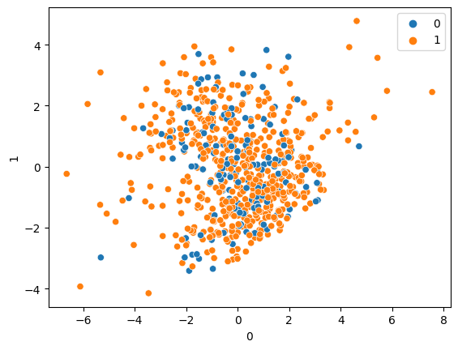

```python
sns.scatterplot(x=pca_std[0],y=pca_std[1],hue=agg_pred)
```

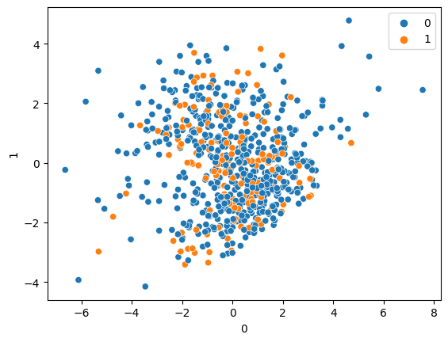

```python
sns.scatterplot(x=pca_std[0],y=pca_std[1],hue=km_pred)
```

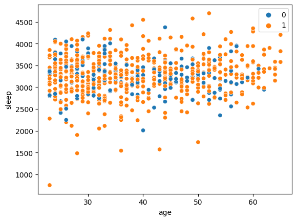

```python
sns.scatterplot(x=df['age'],y=df['sleep'],hue=agg_pred)
```

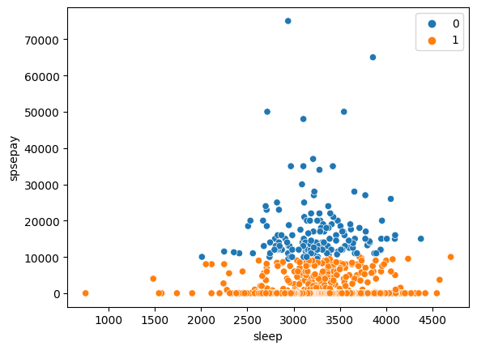

```python
sns.scatterplot(x=df['sleep'],y=df['spsepay'],hue=agg_pred)
```

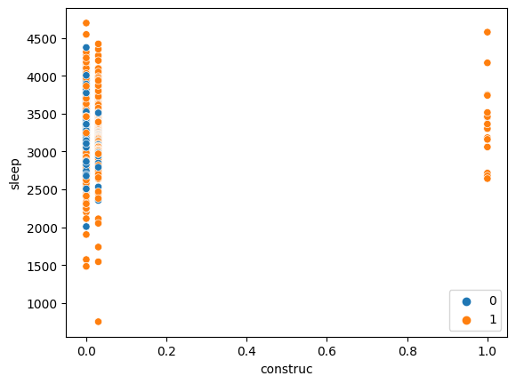

```python
sns.scatterplot(x=df['construc'],y=df['sleep'],hue=agg_pred)
```

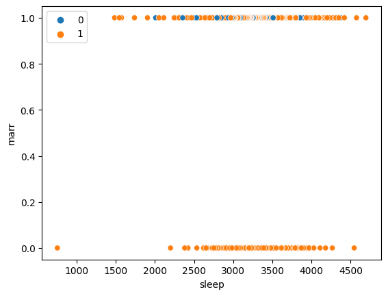

```python
sns.scatterplot(x=df['sleep'],y=df['marr'],hue=agg_pred)
```

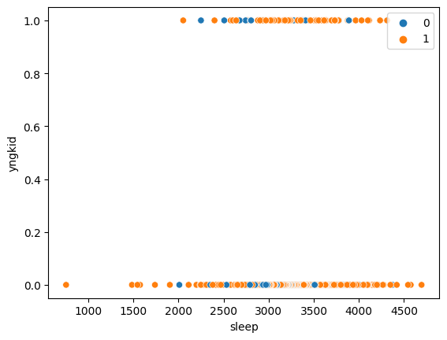

```python
sns.scatterplot(x=df['sleep'],y=df['yngkid'],hue=agg_pred)
```

### **Storytelling/Impact**

The impact that these models could cause go both ways, and could easily be very useful or very hurtful. Should the models be unreliable, it could cause reccomendations to those that don't really need them (which if perscription drugs are involved could cause a major problem). However, should these models be useful, and someone especially greedy, a monopoly could be developed, only allowing a small number of individuals to benefit from this research.

### **References**

https://www.kaggle.com/datasets/kapturovalexander/sleep-patterns

https://www.ncbi.nlm.nih.gov/pmc/articles/PMC3634295/